# INFIX, PREFIX, POSTFIX

Pada ekspressi tersebut, terdapat ambiguitas, yaitu apakah A + B diselesaikan terlebih dahulu ataukah B * C yang harus diselesaikan terlebih dahulu. Ambiguitas ini dapat diatasi dengan konsep operator precedence. Pada operator precedence, operator-operator dibagi menjadi beberapa level berdasarkan prioritas urutan penyelesaian. Pada contoh ekspressi aritmatik A + B * C, berdasarkan operator precedence, maka urutan penyelesaian adalah B * C kemudian hasilnya ditambahkan dengan A. Permasalahan terjadi ketika pada ekspressi aritmatik A + B * C, A + B ingin diselesaikan terlebih dahulu. Untuk penyelesaian ekspressi aritmatik yang tidak sesuai dengan urutan operator precedence, maka tanda '( )' sangatlah diperlukan, sehingga operasi tersebut menjadi (A + B) * C. Tanda '( )' tidaklah diperlukan pada ekspressi aritmatik prefix dan postfix. Pada ekspressi aritmatik **prefix**, operator mendahului operand, sedangkankan ekspressi aritmatik **postfix**, operator ditulis setelah operand.

Berikut contoh ekspressi aritmatik infix dan konversinya ke prefix dan postfix.

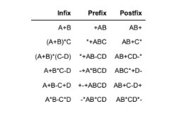

```python
class Stack:
    def __init__(self):
        self.items = []

    def push(self, item):
        self.items.append(item)

    def pop(self):
        return self.items.pop()

    def peek(self):
        return self.items[-1]

    def isEmpty(self):
        return self.items == []
```

```python
#infix ke postfix
def infix_to_postfix(expr):
    prec = {'+':1, '-':1, '*':2, '/':2}
    stack = Stack()
    output = []

    for token in expr:
        if token.isalnum():
            output.append(token)
        elif token == '(':
            stack.push(token)
        elif token == ')':
            while stack.peek() != '(':
                output.append(stack.pop())
            stack.pop()
        else:
            while (not stack.isEmpty()) and stack.peek() != '(' and prec[stack.peek()] >= prec[token]:
                output.append(stack.pop())
            stack.push(token)

    while not stack.isEmpty():
        output.append(stack.pop())

    return " ".join(output)
```

```python
print(infix_to_postfix("A+B*C"))
```

```
A B C * +
```

```python
#infix ke prefix
def infix_to_prefix(expr):
    expr = expr[::-1]

    expr = list(expr)
    for i in range(len(expr)):
        if expr[i] == '(':
            expr[i] = ')'
        elif expr[i] == ')':
            expr[i] = '('

    expr = "".join(expr)

    postfix = infix_to_postfix(expr)
    return postfix[::-1]
```

```python
print(infix_to_prefix("A+B*C"))
```

```
+ A * B C
```

```python
def parenthesesCheck(strMath):
    kurung = {')': '(', '}': '{', ']': '['}
    kurungBuka = kurung.values()
    kurungTutup = kurung.keys()

    temp = []   # gunakan list sebagai stack
    matched = True

    for ch in strMath:

        # Jika kurung buka → push
        if ch in kurungBuka:
            temp.append(ch)

        # Jika kurung tutup → cek pasangan
        elif ch in kurungTutup:
            if not temp:
                return "Kelebihan kurung Tutup"
            else:
                tempKurung = temp.pop()
                if tempKurung == kurung[ch]:
                    matched = matched and True
                else:
                    matched = False

    # Setelah selesai looping
    if temp:
        return "Kelebihan Kurung Buka"

    if matched:
        return "OK"
    else:
        return "Tidak Cocok kurungnya"
```

```python
parenthesesCheck('{5+2}*3')
```

[output not shown]

```python
def evaluatePost(postStr):
    operandStack = []
    operator = '+-/*'

    for i in postStr:
        if i not in operator:
            operandStack.append(i)
        else:
            oprnd2 = operandStack.pop()
            oprnd1 = operandStack.pop()

            if i == '+':
                result = float(oprnd1) + float(oprnd2)
            elif i == '-':
                result = float(oprnd1) - float(oprnd2)
            elif i == '*':
                result = float(oprnd1) * float(oprnd2)
            else:
                result = float(oprnd1) / float(oprnd2)

            operandStack.append(result)

    return operandStack.pop()
```

```python
print(evaluatePost('456*-'))
```

```
-26.0
```

```python
def prefixToInfix(prefix):
    stack = []
    operator = "+-*/"

    for i in reversed(prefix):
        if i not in operator:
            stack.append(i)
        else:
            op1 = stack.pop()
            op2 = stack.pop()
            exp = "(" + op1 + i + op2 + ")"
            stack.append(exp)

    return stack.pop()
```

```python
print(prefixToInfix("+A*BC"))
```

```
(A+(B*C))
```

```python
def postfixToInfix(postfix):
    stack = []
    operator = "+-*/"

    for i in postfix:
        if i not in operator:
            stack.append(i)
        else:
            op2 = stack.pop()
            op1 = stack.pop()
            exp = "(" + op1 + i + op2 + ")"
            stack.append(exp)

    return stack.pop()
```

```python
print(postfixToInfix("ABC*+"))
```

```
(A+(B*C))
```